# ETC5521: Diving Deeply into Data Exploration

Working with a single variable, making transformations, detecting outliers, using robust statistics

Professor Di Cook

Department of Econometrics and Business Statistics

## Outline

- Features to read from a plot of a single quantitative example
- Variety of ways to display a single variable and the pros and cons
- Methods to compute null samples
- Numerical summaries
- Transformations (to symmetrise)
- Handling missing values
- Plotting a single categorical variable
- Ordering categories

## Quantitative variables

## Features of a single quantitative variable

| Feature | Example | Description |
| --- | --- | --- |
| Asymmetry |  | The distribution is not symmetrical. |
| Outliers |  | Some observations are that are far from the rest. |
| Multimodality |  | There are more than one "peak" in the observations. |
| Gaps |  | Some continuous interval that are contained within the range but no observations exists. |
| Heaping |  | Some values occur unexpectedly often. |
| Discretized |  | Only certain values are found, e.g. due to rounding. |
| Implausible |  | Values outside of plausible or likely range. |

## Example: election (1/5)

First preference votes for the Greens from the 2019 Federal election

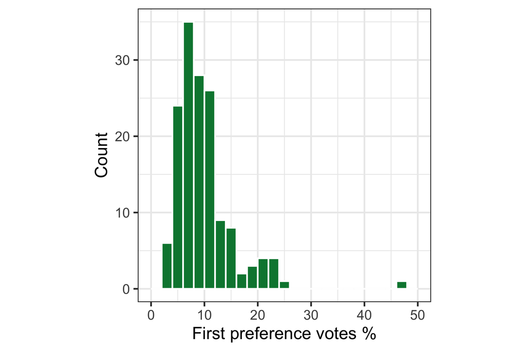

```r
df1 <- read_csv(here::here("data/HouseFirstPrefsByCandidateByVoteTypeDownload-24310.csv"),
  skip = 1,
  col_types = cols(
    .default = col_character(),
    OrdinaryVotes = col_double(),
    AbsentVotes = col_double(),
    ProvisionalVotes = col_double(),
    PrePollVotes = col_double(),
    PostalVotes = col_double(),
    TotalVotes = col_double(),
    Swing = col_double()
  )
)
tdf3 <- df1 |>
  group_by(DivisionID) |>
  summarise(
    DivisionNm = unique(DivisionNm),
    State = unique(StateAb),
    votes_GRN = TotalVotes[which(PartyAb == "GRN")],
    votes_total = sum(TotalVotes)
  ) |>
  mutate(perc_GRN = votes_GRN / votes_total * 100)
tdf3 |>
  ggplot(aes(perc_GRN)) +
  geom_histogram(color = "white",
    fill = "#00843D",
    breaks = seq(0, 50, 2)) +
  labs(
    x = "First preference votes %",
    y = "Count"
  )
```

- -
- Patterns
- Analysis
- What is the pattern?
- What are the implications for an analysis?
- Asymmetric: Skewed right
- One outlier
- Multimodal (?)
- Greens won one seat in this election
- To have a chance of winning an electorate a party needs to be one of the top first preferences %. Greens are not close on any other electorate.
- Is the small bump a set of electorates that could be targeted by Greens in the next election?

## Example: wordle (2/5)

Distribution of my daily wordle attempts

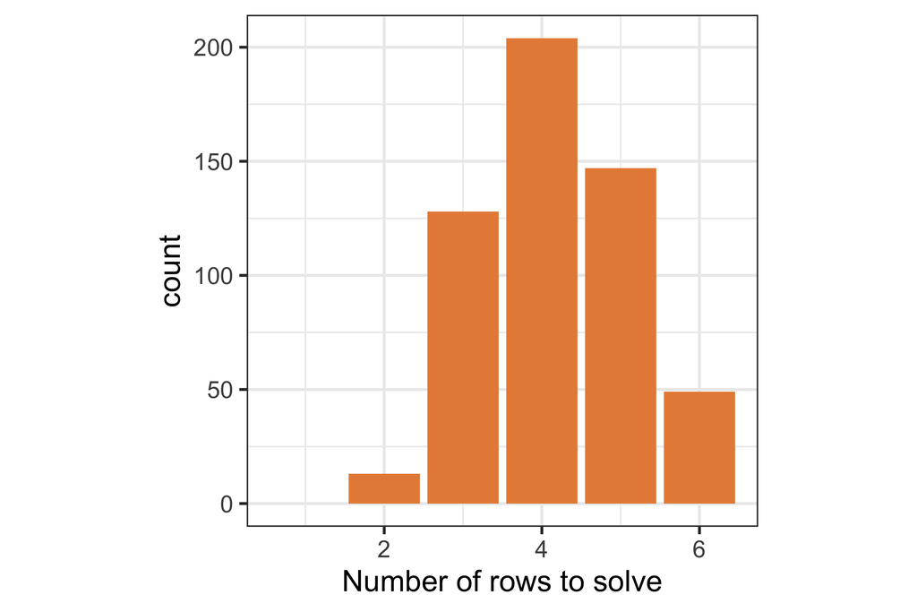

```r
wordle <- tibble(rows = c(1:6), count = c(0, 13, 128, 204, 147, 49))
ggplot(wordle, aes(x=rows, y=count)) +
  geom_col(fill = "#e78c45") +
  #scale_x_discrete(breaks=1:6, labels=1:6) +
  xlab("Number of rows to solve")
```

- -
- Patterns
- Analysis
- What is the pattern?
- What are the implications for an analysis?
- symmetric (?)
- barrier (?)
- Distribution of rows needed to solve puzzle, likely cannot be a binomial?

## Example: olive oil (3/5)

% composition of eicosenoic acid in Italian olive oil samples

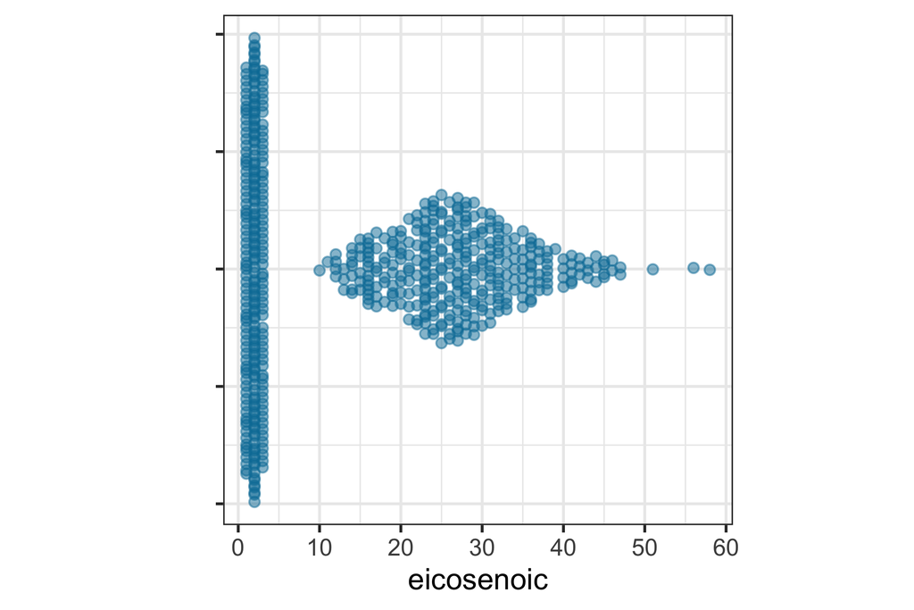

```r
olive <- read_csv(here::here("data/olive.csv")) |>
  rename(id = `...1`)
olive |>
  ggplot(aes(x=eicosenoic, y=1)) +
    geom_quasirandom(
      colour = "#007BA5",
      alpha = 0.5) +
    scale_x_continuous(breaks = seq(0, 100, 10)) +
    ylab("") +
    theme(axis.text.y = element_blank())
```

- -
- Patterns
- Analysis
- What is the pattern?
- What are the implications for an analysis?
- gap
- Another variable might explain two groups

## Example: air quality (4/5)

Concentration of SO2 at sensors across Melbourne throughout 2020.

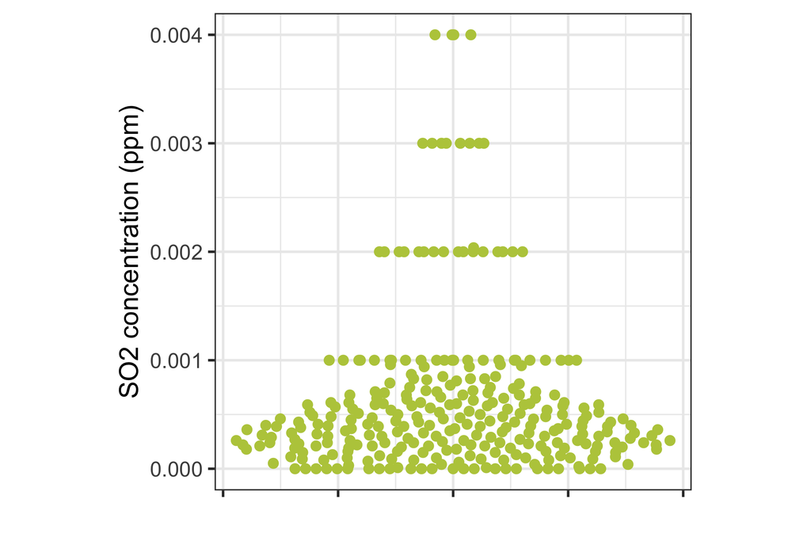

```r
melb_air <- read_csv(here::here("data/melb_air.csv"))
ggplot(melb_air, aes(x = 1, y = so2)) +
  geom_quasirandom(colour = "#b9ca4a") +
  xlab("") +
  ylab("SO2 concentration (ppm)") +
  theme(axis.text.x = element_blank())
```

- -
- Patterns
- Analysis
- What is the pattern?
- What are the implications for an analysis?
- discrete: mix of two distributions
- Resolution for analysis may need to be reduced to the lowest

## Example: air travel (5/5)

Air traffic in and out of New York City airports

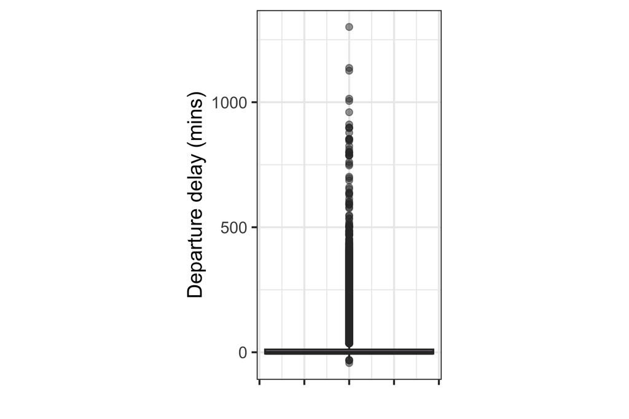

```r
library(nycflights13)
ggplot(flights, aes(x = 1, y = dep_delay)) +
  geom_boxplot(fill = "#c397d8", alpha = 0.5) +
  xlab("") +
  ylab("Departure delay (mins)") +
  theme(aspect.ratio = 2,
    axis.text.x = element_blank())
```

- -
- Patterns
- Analysis
- What is the pattern?
- What are the implications for an analysis?
- outliers
- symmetric (?)
- implausible (?)
- 50% of observations are within a few minutes of scheduled departure time
- Check the values of the extremes
- Maybe bin up the data, or remove values close to 0, so that the distribution of delayed flights can be examined

## Plot type can affect detectability

- Greens
- Oils
- Air
- Re-focus

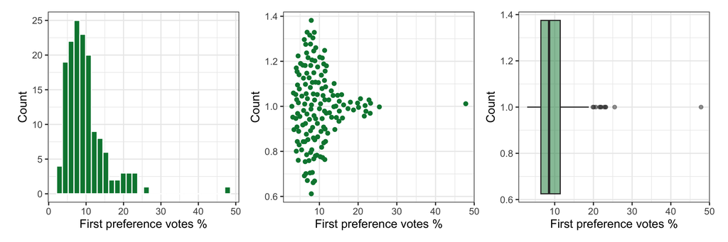

```r
gp1 <- tdf3 |>
  ggplot(aes(perc_GRN)) +
  geom_histogram(color = "white", fill = "#00843D") +
  labs(
    x = "First preference votes %",
    y = "Count"
  )
gp2 <- tdf3 |>
  ggplot(aes(perc_GRN)) +
  geom_quasirandom(color = "#00843D") +
  labs(
    x = "First preference votes %",
    y = "Count"
  )
gp2 <- tdf3 |>
  ggplot(aes(x = perc_GRN, y = 1)) +
  geom_quasirandom(color = "#00843D") +
  labs(
    x = "First preference votes %",
    y = "Count"
  )
gp3 <- tdf3 |>
  ggplot(aes(x = perc_GRN, y = 1)) +
  geom_boxplot(fill = "#00843D", alpha=0.5) +
  labs(
    x = "First preference votes %",
    y = "Count"
  )
gp1 + gp2 + gp3 + plot_layout(ncol=3)
```

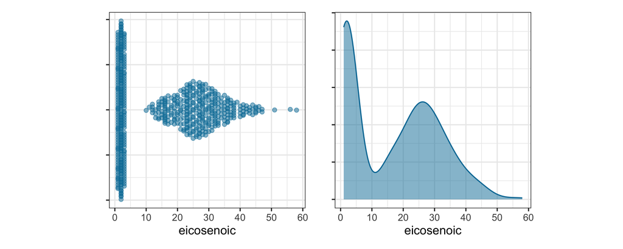

```r
op1 <- olive |>
  ggplot(aes(x=eicosenoic, y=1)) +
    geom_quasirandom(
      colour = "#007BA5",
      alpha = 0.5) +
    scale_x_continuous(breaks = seq(0, 100, 10)) +
    ylab("") +
    theme(axis.text.y = element_blank())
op2 <- olive |>
  ggplot(aes(x=eicosenoic)) +
    geom_density(
      colour = "#007BA5",
      fill = "#007BA5",
      alpha = 0.5) +
    scale_x_continuous(breaks = seq(0, 100, 10)) +
    ylab("") +
    theme(axis.text.y = element_blank())
op1 + op2 + plot_layout(ncol=2)
```

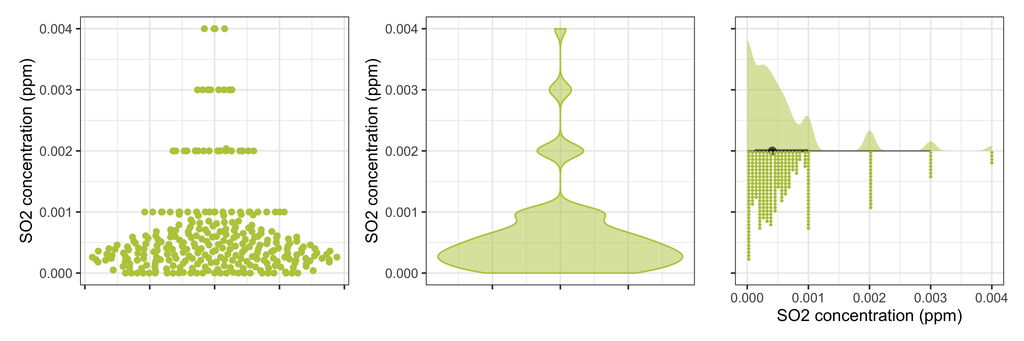

```r
ap1 <- ggplot(melb_air, aes(x = 1, y = so2)) +
  geom_quasirandom(colour = "#b9ca4a") +
  xlab("") +
  ylab("SO2 concentration (ppm)") +
  theme(axis.text.x = element_blank())
ap2 <- ggplot(melb_air, aes(x = 1, y = so2)) +
  geom_violin(
    quantiles = c(0.25, 0.5, 0.75),
    quantile.colour = "white",
    colour = "#b9ca4a", fill = "#b9ca4a", alpha=0.5) +
  xlab("") +
  ylab("SO2 concentration (ppm)") +
  theme(axis.text.x = element_blank())
ap3 <- ggplot(melb_air, aes(x = so2, y = 1)) +
  stat_halfeye(fill = "#b9ca4a", alpha=0.5) +
  stat_dots(side = "bottom",
    colour = "#b9ca4a") +
  ylab("") +
  xlab("SO2 concentration (ppm)") +
  theme(axis.text.y = element_blank())
ap1 + ap2 + ap3 + plot_layout(ncol=3)
```

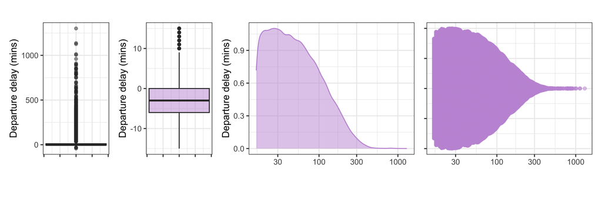

```r
fp1 <- ggplot(flights, aes(x = 1, y = dep_delay)) +
  geom_boxplot(fill = "#c397d8", alpha = 0.5) +
  xlab("") +
  ylab("Departure delay (mins)") +
  theme(aspect.ratio = 2,
    axis.text.x = element_blank())
fp2 <- flights |>
  filter(between(dep_delay, -15, 15)) |>
  ggplot(aes(x = 1, y = dep_delay)) +
  geom_boxplot(fill = "#c397d8", alpha = 0.5) +
  xlab("") +
  ylab("Departure delay (mins)") +
  theme(aspect.ratio = 2,
    axis.text.x = element_blank())
fp3 <- flights |>
  filter(dep_delay > 15) |>
  ggplot(aes(x = dep_delay)) +
  geom_density(colour = "#c397d8",
    fill = "#c397d8",
    alpha = 0.5) +
  scale_x_log10() +
  xlab("") +
  ylab("Departure delay (mins)") +
  theme(aspect.ratio = 0.8)
fp4 <- flights |>
  filter(dep_delay > 15) |>
  ggplot(aes(x = dep_delay, y = 1)) +
  geom_quasirandom(colour = "#c397d8",
    alpha = 0.5) +
  scale_x_log10() +
  xlab("") +
  ylab("Departure delay (mins)") +
  theme(aspect.ratio = 0.8,
    axis.text.y = element_blank(),
    axis.title.y = element_blank())
fp1 + fp2 + fp3 + fp4 + plot_layout(ncol=4)
```

## Activity: Movies

**Your turn**

1. Grab a copy of the movies data

```r
data(movies, package = "ggplot2movies")
```

2. Make a plot of the `length` of the movies
3. Describe the structure
4. Play with the type of plot, and the scale, and describe some surprising aspects of movie length

## Generating null samples

## Simulation

- Normal/Gaussian: `rnorm(n, mean = 0, sd = 1)`
- Uniform: `runif(n, min = 0, max = 1)`
- Exponential: `rexp(n, rate = 1)`
- Log-normal: `rlnorm(n, meanlog = 0, sdlog = 1)`
- Gamma: `rgamma(n, shape, rate = 1)`
- Beta: `rbeta(n, shape1, shape2)`
- Chi-square: `rchisq(n, df)`
- Student’s t: `rt(n, df)`
- Weibull: `rweibull(n, shape, scale = 1)`
- Cauchy: `rcauchy(n, location = 0, scale = 1)`
- Binomial: `rbinom(n, size, prob)`
- Negative binomial: `rnbinom(n, size, prob)`
- Geometric: `rgeom(n, prob)`

To generate null samples that might match your data, try `fitdistrplus`:

- `fit <- fitdist(your_data, "norm")`
- `params <- fit$estimate`
- `simulated <- rnorm(n, mean = params["mean"], sd = params["sd"])`

Or compute summary statistics:

**Normal**

```
mu    <- mean(your_data)
sigma <- sd(your_data)
```

**Exponential**

```
rate <- 1 / mean(your_data)
```

## Example: election (1/2)

- Exponential
- Beta
- Learn

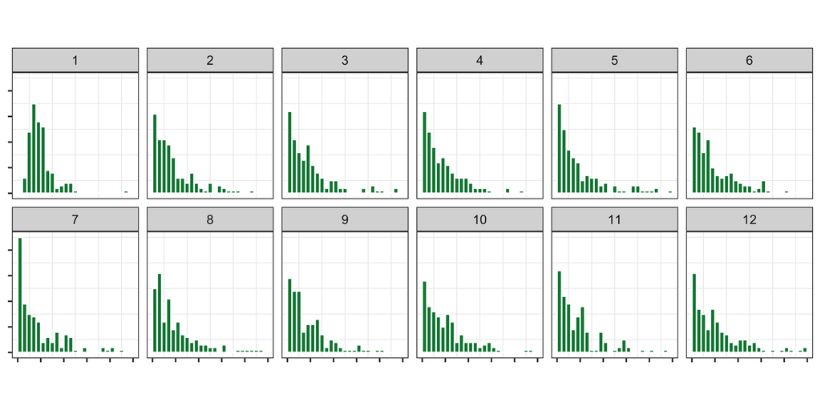

```r
set.seed(241)
l <- lineup(null_dist("perc_GRN", "exp"), tdf3, n=12, pos=1)
ggplot(l,
       aes(x=perc_GRN)) +
  geom_histogram(color = "white",
    fill = "#00843D",
    breaks = seq(0, 50, 2)) +
  xlim(c(0, 50)) +
  facet_wrap(~.sample, ncol=6) +
  theme(axis.text = element_blank(),
        axis.title = element_blank(),
        panel.grid.major = element_blank())
```

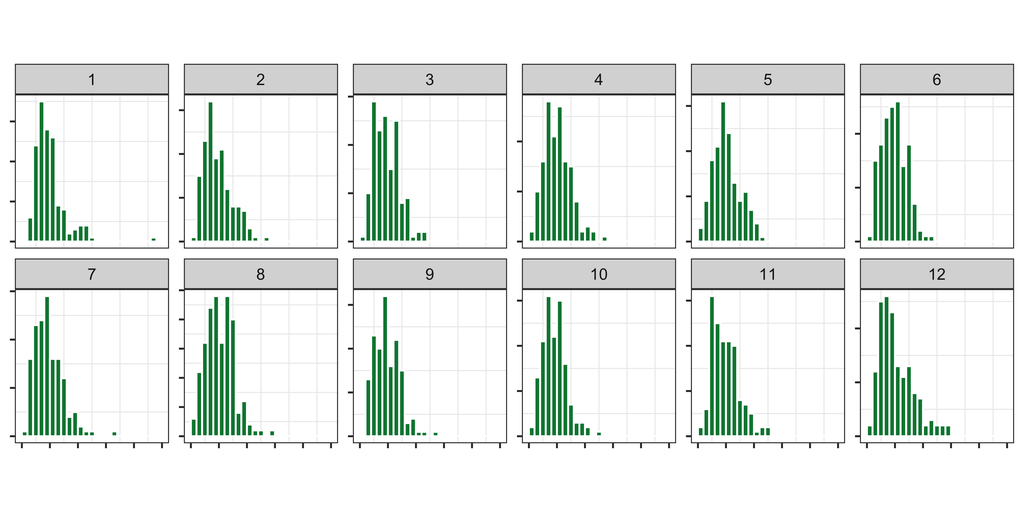

```r
library(fitdistrplus)
fit <- fitdist(tdf3$perc_GRN / 100, "beta")

set.seed(446)
l2 <- tdf3 |>
  select(perc_GRN) |>
  mutate(.sample = 1)
for (i in 1:11) {
  x <- rbeta(nrow(tdf3), fit$estimate[1], fit$estimate[2])*100
  d <- tibble(perc_GRN = x,
     .sample = i+1)
  l2 <- bind_rows(l2, d)
}
ggplot(l2,
       aes(x=perc_GRN)) +
  geom_histogram(color = "white",
    fill = "#00843D",
    breaks = seq(0, 50, 2)) +
  xlim(c(0, 50)) +
  facet_wrap(~.sample, ncol=6, scale="free_y") +
  theme(axis.text = element_blank(),
        axis.title = element_blank(),
        panel.grid.major = element_blank())
```

- The bump is *may not be unusual* for a sample from a standard distribution.
- The single outlier is not typically seen in simulated samples.

## Example: wordle (2/2)

- Binomial
- Learn

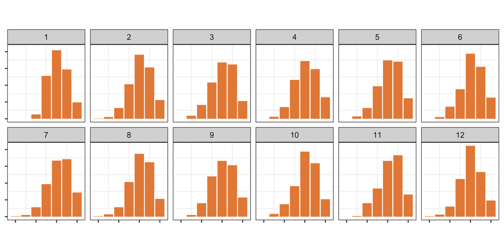

```r
wordle_uncount <- uncount(wordle, count)
p <- mean(wordle_uncount$rows)/6
set.seed(501)
wl <- wordle |>
  mutate(.sample = 1)
for (i in 1:11) {
  x <- rbinom(nrow(wordle_uncount), 6, p)
  d <- tibble(rows = x) |>
    count(rows) |>
    rename(count = n) |>
    mutate(.sample = i+1)
  wl <- bind_rows(wl, d)
}
ggplot(wl,
       aes(x=rows, y=count)) +
  geom_col(fill = "#e78c45") +
  facet_wrap(~.sample, ncol=6) +
  theme(axis.text = element_blank(),
        axis.title = element_blank(),
        panel.grid.major = element_blank())
```

The distribution of actual wordle results is different from samples from a binomial

- counts for 1-2 rows is too low
- peak at 4 is too high

## Numerical measures of a single quantitative variables

## Central tendency and dispersion

- A measure of *central tendency*, e.g. mean, median and mode
- A measure of *dispersion* (also called variability or spread), e.g. variance, standard deviation and interquartile range
- There are other measures, e.g. *skewness* and *kurtosis* that measures “tailedness”, but these are not as common as the measures of first two
- The mean is also the *first moment* and variance, skewness and kurtosis are *second, third, and fourth central moments*

## Robust measure of central tendency

- **Mean** is a non-robust measure of location.
- **Median** is the 50% quantile of the observations
- **Trimmed mean** is the sample mean after discarding observations at the tails.
- **Winsorized mean** is the sample mean after replacing observations at the tails with the minimum or maximum of the observations that remain.

Both trimmed and Winsorized mean trimmed 20% of the tails.

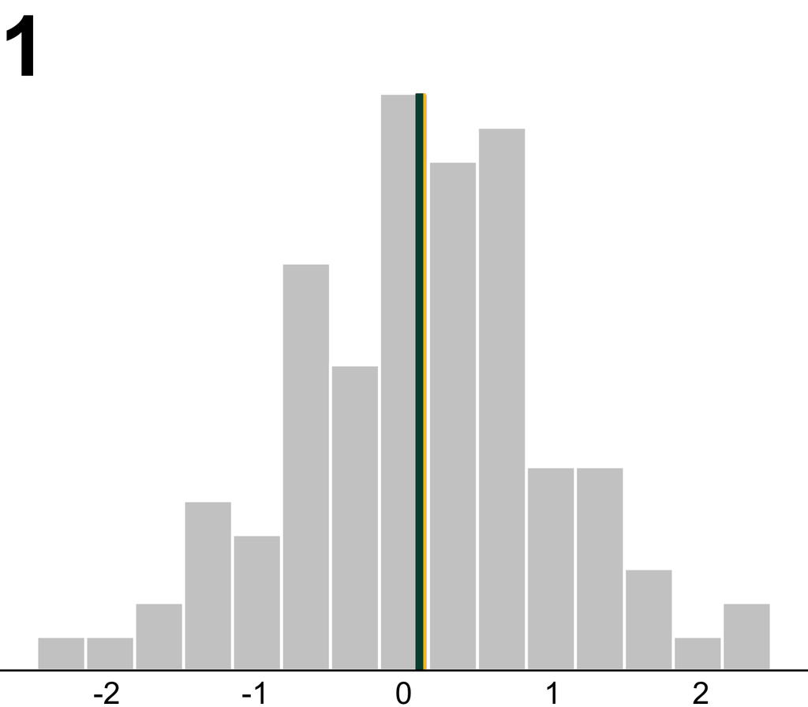

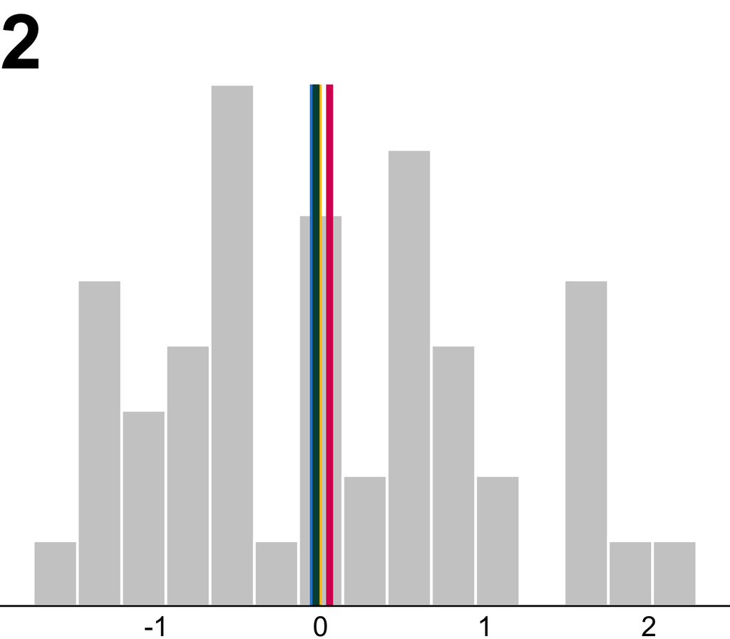

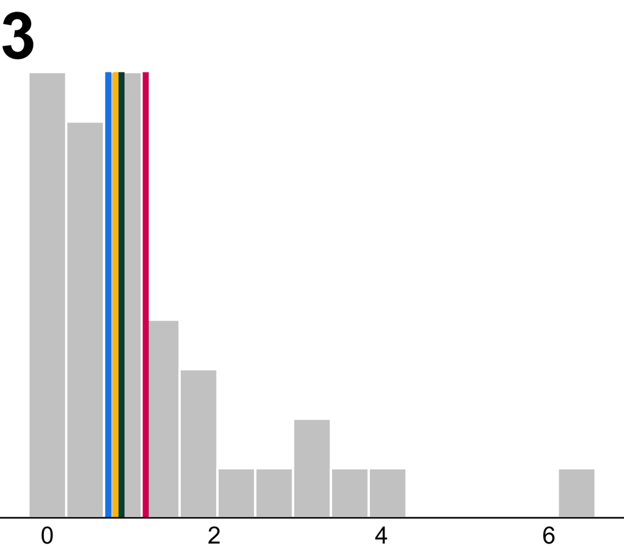

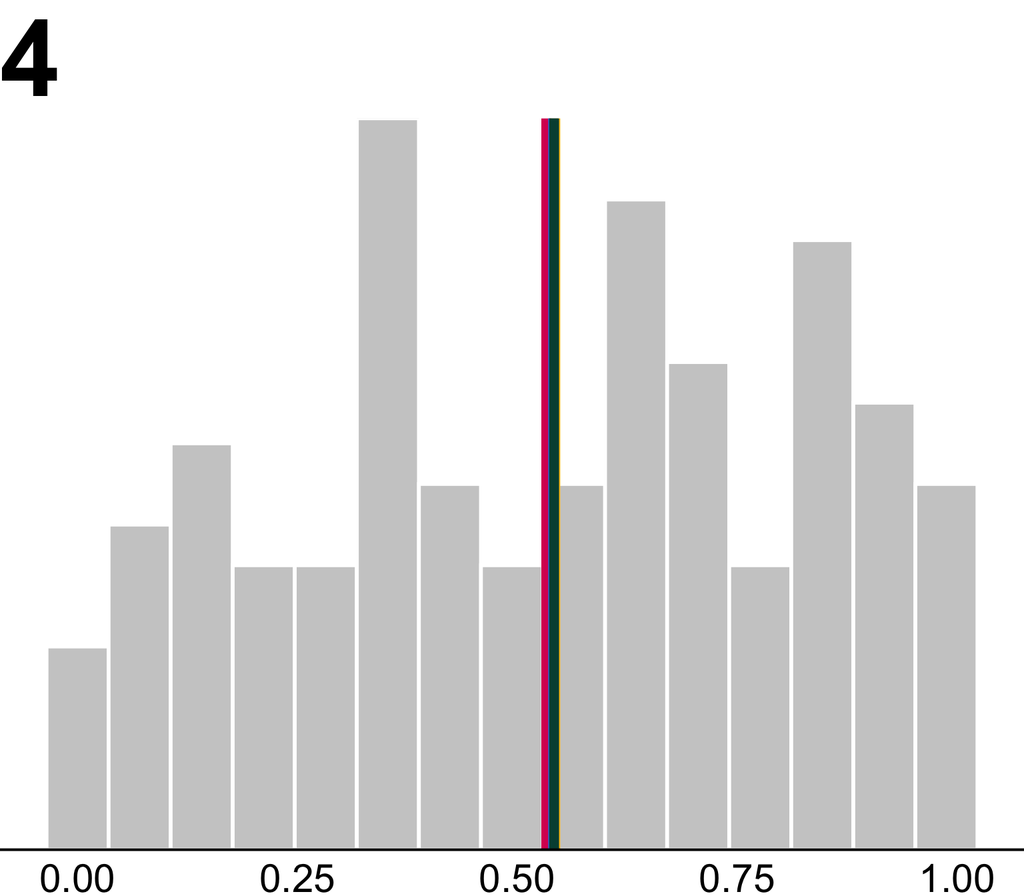

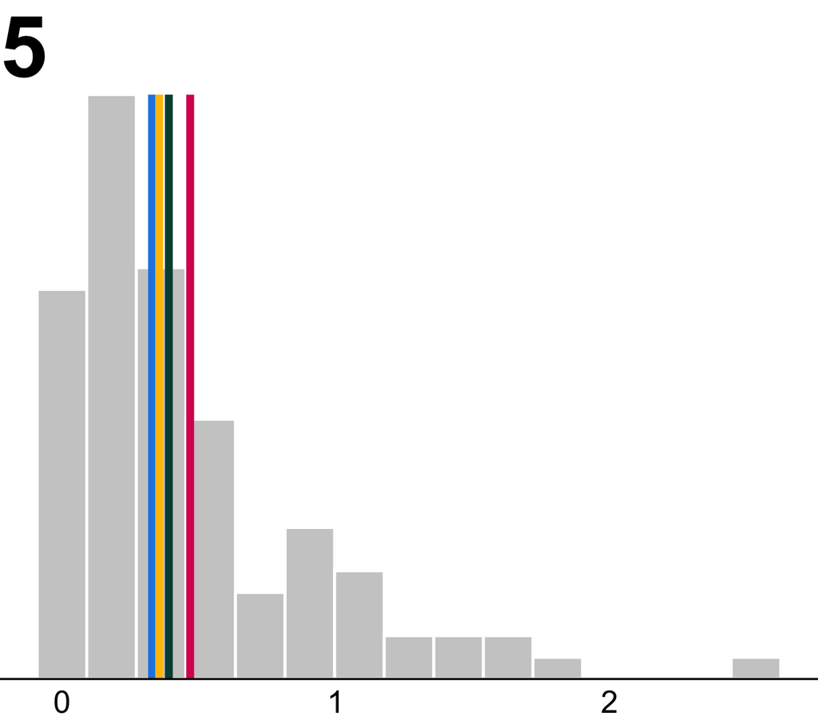

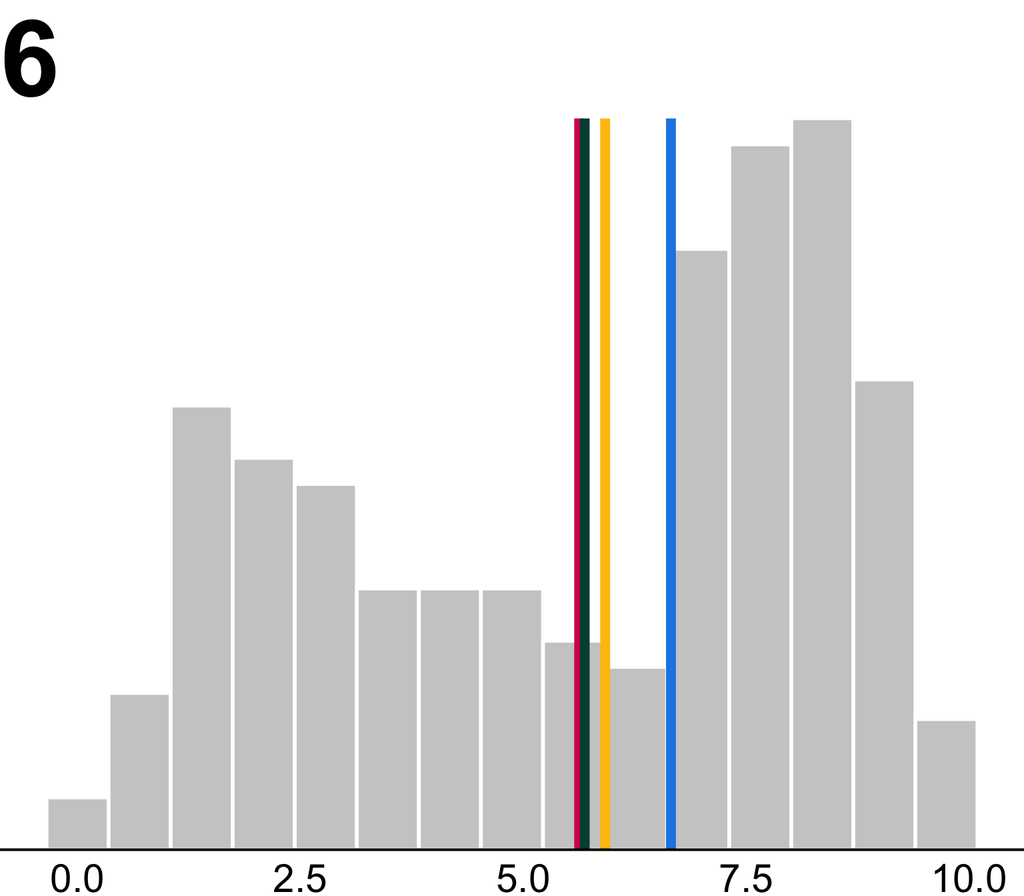

| Plot | Mean | Median | Trimmed Mean | Winsorized Mean |
| --- | --- | --- | --- | --- |
| 1 | 0.109 | 0.114 | 0.120 | 0.103 |
| 2 | 0.054 | -0.045 | -0.016 | -0.029 |
| 3 | 1.177 | 0.729 | 0.820 | 0.888 |
| 4 | 0.533 | 0.541 | 0.543 | 0.542 |
| 5 | 0.468 | 0.329 | 0.355 | 0.390 |
| 6 | 5.626 | 6.656 | 5.918 | 5.688 |

## Robust measure of dispersion

- **Standard deviation** or its square, **variance**, is a popular choice of measure of dispersion but is not robust to outliers
- Standard deviation for sample $x_1, ..., x_n$ is

$$\sqrt{\sum_{i=1}^n \frac{(x_i - \bar{x})^2}{n - 1}}$$

- **Interquartile range** difference between 1st and 3rd quartile, more robust measure of spread
- **Median absolute deviance** (MAD) is even more robust

$$\text{median}(|x_i - \text{median}(x_i)|)$$

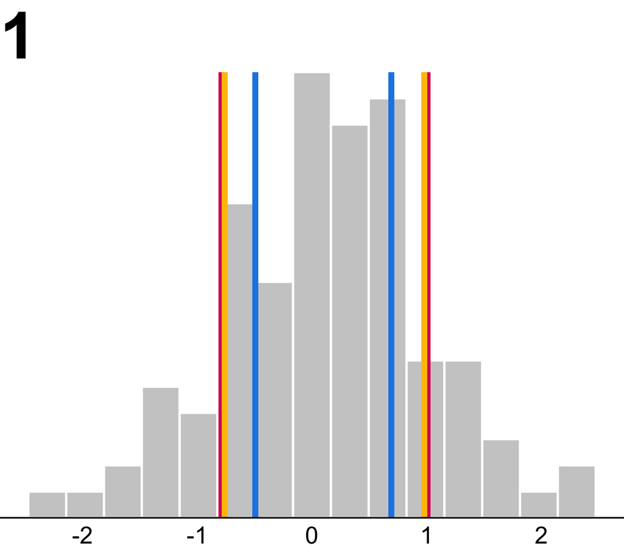

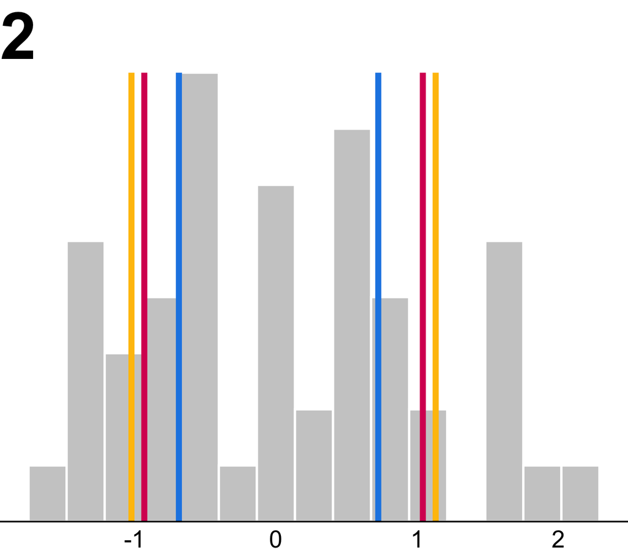

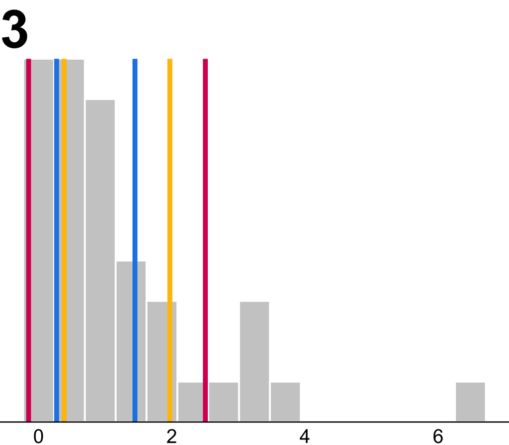

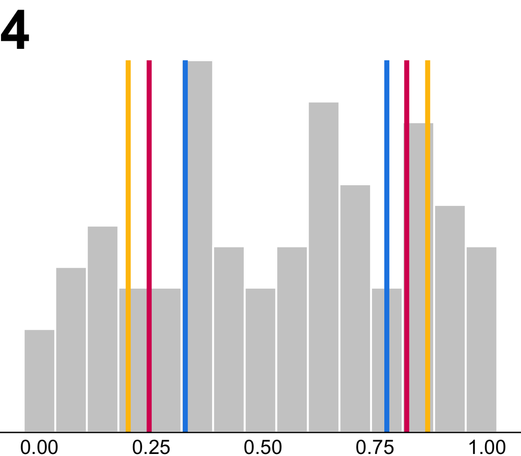

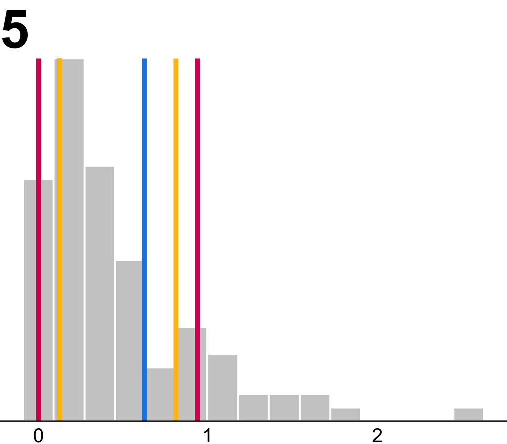

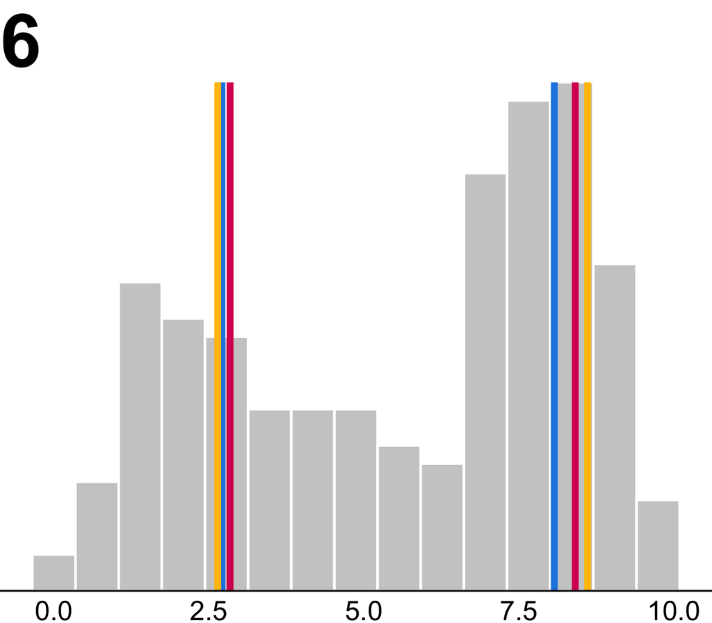

| Plot | Measure of dispersion SD | Measure of dispersion IQR | Measure of dispersion MAD | Skewness | Kurtosis |
| --- | --- | --- | --- | --- | --- |
| 1 | 0.90 | 1.19 | 0.87 | -0.072 | 3.0 |
| 2 | 0.99 | 1.41 | 1.08 | 0.358 | 2.2 |
| 3 | 1.33 | 1.18 | 0.79 | 1.944 | 7.2 |
| 4 | 0.29 | 0.45 | 0.34 | -0.126 | 1.8 |
| 5 | 0.47 | 0.50 | 0.34 | 1.691 | 6.4 |
| 6 | 2.78 | 5.36 | 2.98 | -0.351 | 1.7 |

## Example: election (1/3)

- 📊
- R

| Mean | % of first preference for the Greens Median | % of first preference for the Greens SD | % of first preference for the Greens MAD | % of first preference for the Greens IQR | % of first preference for the Greens Skewness | Kurtosis |
| --- | --- | --- | --- | --- | --- | --- |
| 9.9 | 8.5 | 5.6 | 3.8 | 5 | 2.7 | 16 |

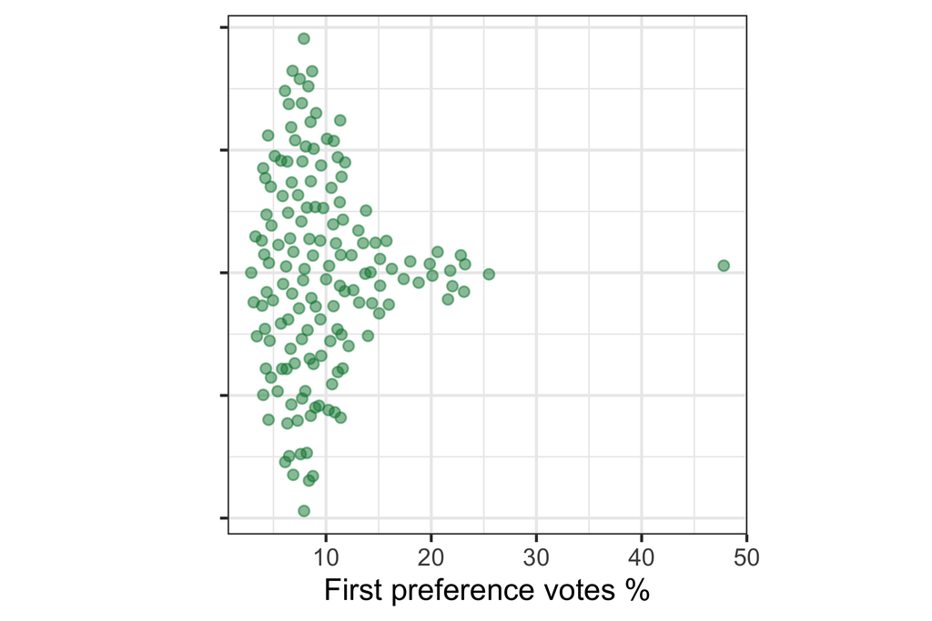

- Why are the means and the medians different?
- How are the standard deviations and the interquartile ranges similar or different?
- Are there some other numerical statistics we should show?

```r
tdf3 |>
 summarise(
    mean = mean(perc_GRN),
    median = median(perc_GRN),
    sd = sd(perc_GRN),
    mad = mad(perc_GRN),
    iqr = IQR(perc_GRN),
    skewness = moments::skewness(perc_GRN),
    kurtosis = moments::kurtosis(perc_GRN)
  ) |>
  knitr::kable(col.names = c("Mean", "Median", "SD", "MAD", "IQR", "Skewness", "Kurtosis"), digits = 3) |>
  kableExtra::kable_classic() |>
  kableExtra::add_header_above(c(" ", "% of first preference for the Greens" = 5, " "))
```

## Example: olive oil (2/3)

- 📊
- R

| % composition of eicosenoic acid Mean | % composition of eicosenoic acid Median | % composition of eicosenoic acid SD | % composition of eicosenoic acid MAD | % composition of eicosenoic acid IQR | % composition of eicosenoic acid Skewness | % composition of eicosenoic acid Kurtosis |
| --- | --- | --- | --- | --- | --- | --- |
| 16 | 17 | 14 | 21 | 26 | 0.34 | 1.9 |

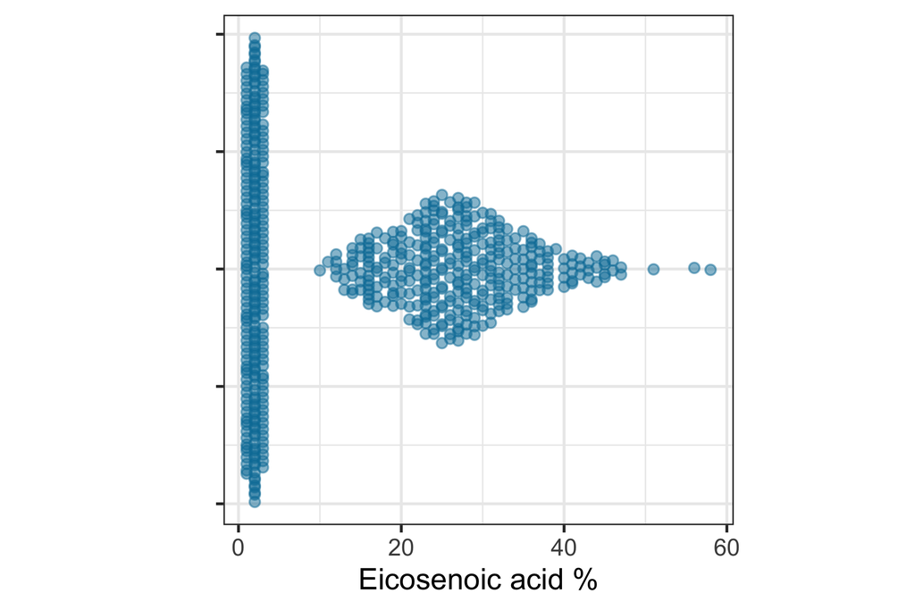

```r
olive |>
  summarise(
    mean = mean(eicosenoic),
    median = median(eicosenoic),
    sd = sd(eicosenoic),
    mad = mad(eicosenoic),
    iqr = IQR(eicosenoic),
    skewness = moments::skewness(eicosenoic),
    kurtosis = moments::kurtosis(eicosenoic)
  ) |>
  knitr::kable(col.names = c("Mean", "Median", "SD", "MAD", "IQR", "Skewness", "Kurtosis"), digits = 3) |>
  kableExtra::kable_classic() |>
  kableExtra::add_header_above(c("% composition of eicosenoic acid" = 7))
```

## Example: air quality (3/3)

- 📊
- R

| SO2 concentration (ppm) Mean | SO2 concentration (ppm) Median | SO2 concentration (ppm) SD | SO2 concentration (ppm) MAD | SO2 concentration (ppm) IQR | SO2 concentration (ppm) Skewness | SO2 concentration (ppm) Kurtosis |
| --- | --- | --- | --- | --- | --- | --- |
| 0.00063 | 0.00041 | 0.00074 | 0.00037 | 0.00051 | 2.5 | 9.7 |

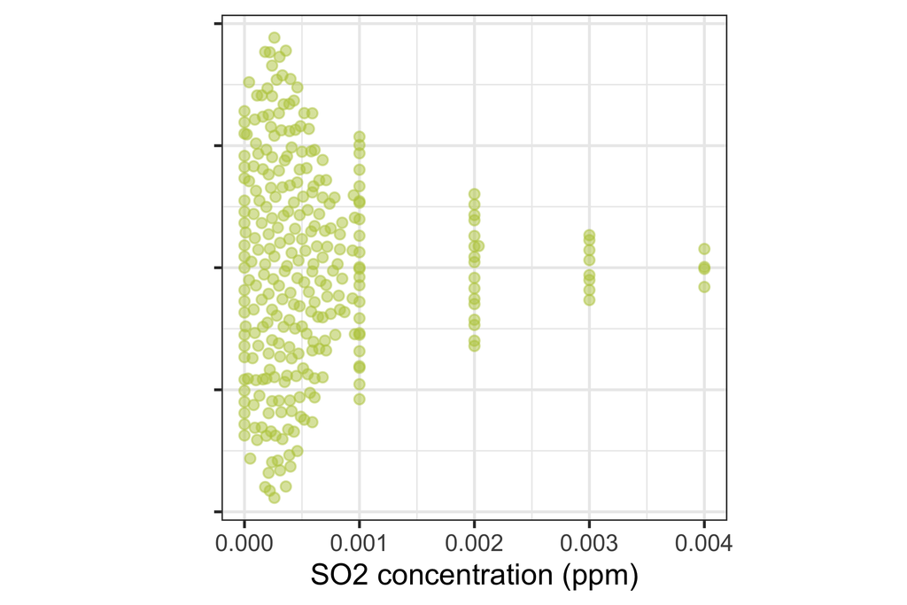

- Why are the mean and the median so different?
- How do the standard deviation and the interquartile range compare?
- What do the skewness and kurtosis values suggest about the shape of the distribution?

```r
melb_air |>
  summarise(
    mean = mean(so2, na.rm = TRUE),
    median = median(so2, na.rm = TRUE),
    sd = sd(so2, na.rm = TRUE),
    mad = mad(so2, na.rm = TRUE),
    iqr = IQR(so2, na.rm = TRUE),
    skewness = moments::skewness(so2, na.rm = TRUE),
    kurtosis = moments::kurtosis(so2, na.rm = TRUE)
  ) |>
  knitr::kable(col.names = c("Mean", "Median", "SD", "MAD", "IQR", "Skewness", "Kurtosis"), digits = 5) |>
  kableExtra::kable_classic() |>
  kableExtra::add_header_above(c("SO2 concentration (ppm)" = 7))
```

## Inference for robust statistics

We have seen the re-sampling methods simulation and permutation used for generating null plots in a lineup. Re-sampling methods can be used with numeric statistics also.

Simulation from distribution, can be used to to check for outliers.

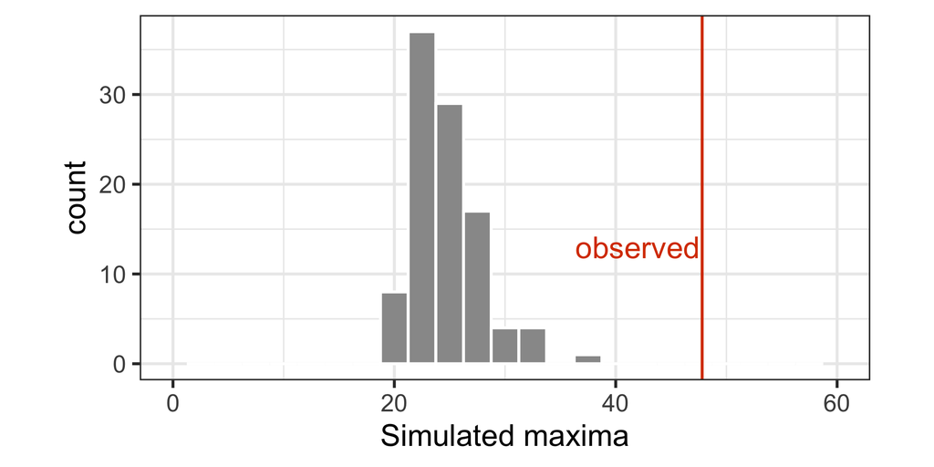

```r
# Estimate the parameters without the outlier
est_r <- fitdist(tdf3$perc_GRN[tdf3$perc_GRN < 40]/100, "beta")
# Check fit
# ggplot(tdf3, aes(sample=perc_GRN)) + stat_qq(distribution = stats::qexp, dparams = est_r) + stat_qq_line(distribution = stats::qexp, dparams = est_r)
set.seed(912)
samp <- matrix(rbeta(n=151*100,
  shape1=est_r$estimate[1],
  shape2=est_r$estimate[2])*100, ncol=100, byrow=TRUE)
samp_max <- apply(samp, 2, max)
samp_max_df <- tibble(m = samp_max)
ggplot(samp_max_df, aes(x=m)) +
  geom_histogram(binwidth=2.5, fill="grey60",
    colour="white") +
  xlim(c(0, 60)) +
  geom_vline(xintercept=
    tdf3$perc_GRN[tdf3$perc_GRN > 40], colour="#D93F00") +
  annotate("text", x=42, y=13, label="observed", colour="#D93F00") +
  xlab("Simulated maxima") +
  theme(aspect.ratio = 0.5)
```

We can also compute how many simulated values are more than the observed which gives a simulation $p$-value: 0.

For sample means, conventional tests provide a means for assessing what might be observed if different samples were taken.

Bootstrapping the current sample, can be used for robust statistics. If we have a sample of values:

```
[1] 2 2 3 6 7 7 8 8
```

to bootstrap sample with replacement:

```r
sort(sample(x, replace=TRUE))
```

```
[1] 2 2 3 3 7 7 7 7
```

```r
sort(sample(x, replace=TRUE))
```

```
[1] 2 3 6 6 6 6 8 8
```

Here’s an example of bootstrapping to get a confidence interval for a median.

```
[1] "Median: 6.34"
```

```
[1] "95% CI: ( 4.99 , 9.16 )"
```

## Activity: Air quality

**Your turn**

1. Look at the `pm25` variable in the `melb_air` data (fine particulate matter, µg/m³)
2. Compute both robust (median, MAD, IQR) and non-robust (mean, SD) summary statistics – how much do they disagree, and why?
3. Bootstrap a 95% confidence interval for the median
4. How might these quantities be used to determine reasonable levels of PM25, and indicate extreme values?

## A comment about boxplots (1/2)

- 📊
- data
- R

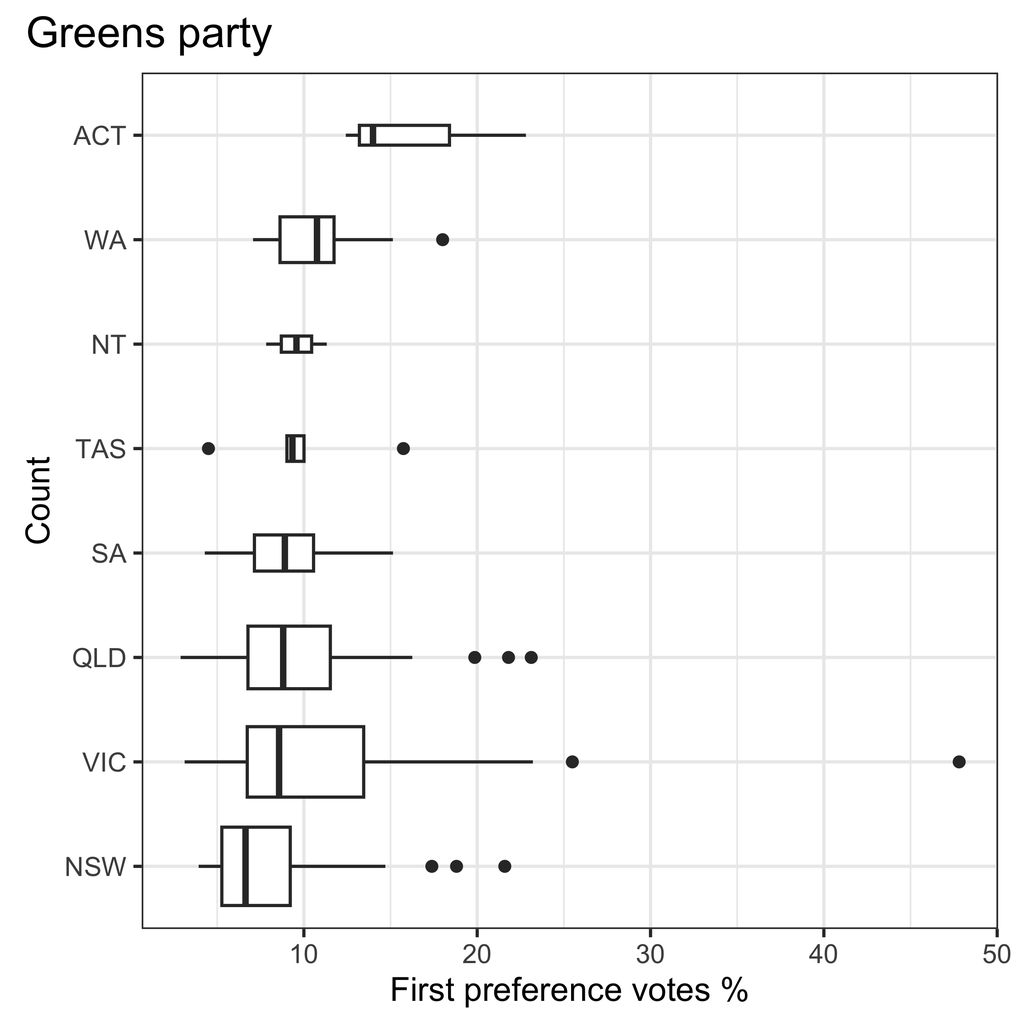

```r
tdf3 |>
  mutate(State = fct_reorder(State, perc_GRN)) |>
  ggplot(aes(perc_GRN, State)) +
  geom_boxplot(varwidth = TRUE) +
  labs(
    x = "First preference votes %",
    y = "Count",
    title = "Greens party"
  )
```

**Where are these electorates?**

The width of the boxplot is proportional to the number of electoral districts in the corresponding state (which is roughly proportional to the population).

```r
tdf3 |>
  mutate(State = fct_reorder(State, perc_GRN)) |>
  ggplot(aes(perc_GRN, State)) +
  geom_boxplot(varwidth = TRUE) +
  labs(
    x = "First preference votes %",
    y = "Count",
    title = "Greens party"
  )
```

## A comment about boxplots (2/2)

- 📊
- data
- R

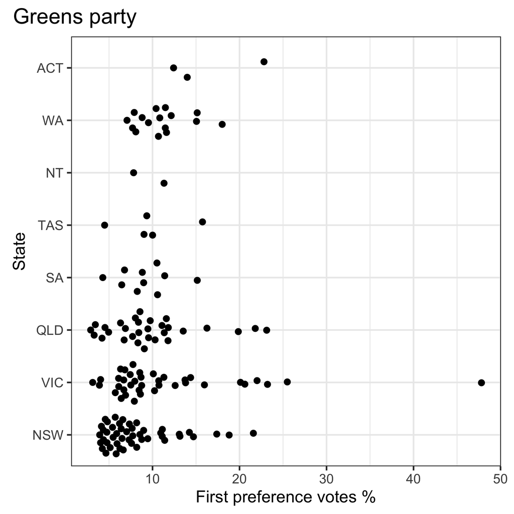

```r
tdf3 |>
  mutate(State = fct_reorder(State, perc_GRN)) |>
  ggplot(aes(perc_GRN, State)) +
  ggbeeswarm::geom_quasirandom(groupOnX = FALSE, varwidth = TRUE) +
  labs(
    x = "First preference votes %",
    y = "State",
    title = "Greens party"
  )
```

**Now what do you notice from this graph that you didn’t notice before?**

- Only two electoral districts in NT.
- And only 3 and 5 electoral districts in ACT and TAS, respectively!
- Boxplots requires 5 points!
- We should have summarised the number of electoral districts for each state with numerical statistics as a first step.
- Also the outlier (yes, safe to call this an outlier!) and the cluster in the Victoria electorates.

```r
tdf3 |>
  mutate(State = fct_reorder(State, perc_GRN)) |>
  ggplot(aes(perc_GRN, State)) +
  ggbeeswarm::geom_quasirandom(groupOnX = FALSE, varwidth = TRUE) +
  labs(
    x = "First preference votes %",
    y = "State",
    title = "Greens party"
  )
```

## Transformations

## Box-Cox

The Box-Cox transformation is a family of power transformations, indexed by a parameter $\lambda$, used to make a variable more symmetric (and closer to normally distributed):

$$y^{(\lambda)} = \begin{cases} \dfrac{y^\lambda - 1}{\lambda}, & \lambda \neq 0 \\[4pt] \log(y), & \lambda = 0 \end{cases}$$

- Only defined for $y > 0$
- $\lambda$ can be chosen to maximise the log-likelihood of the transformed values being normal, e.g. `MASS::boxcox()`
- The transformation is a *guide*: round $\lambda$ to a nearby, interpretable value (e.g. $0$ for $\log$, $0.5$ for $\sqrt{\ }$)

**The ladder of transformations**

Tukey’s ladder of power transformations arranges the Box-Cox family by $\lambda$. Moving *down* the ladder pulls in long right tails; moving *up* the ladder pulls in long left tails.

| $\lambda$ | Transformation | Typical use |
| --- | --- | --- |
| 2 | $y^2$ | strongly left-skewed |
| 1 | $y$ (no change) | roughly symmetric |
| 0.5 | $\sqrt{y}$ | mild right-skew, count data |
| 0 | $\log(y)$ | moderate to strong right-skew |
| -0.5 | $1/\sqrt{y}$ | strong right-skew |
| -1 | $1/y$ | very strong right-skew, e.g. rates |

- Start close to $\lambda=1$ (no transformation) and move up or down the ladder, checking symmetry with a plot after each step
- The further $\lambda$ moves from 1, the stronger the transformation

## Example: air quality (PM2.5)

- 📊
- data
- R

Original `pm25` (µg/m³) – 34 zero values are **shifted by** $+0.1$ before transforming, since Box-Cox requires $y>0$:

```r
pm25 <- melb_air$pm25[!is.na(melb_air$pm25)]
pm25_shift <- pm25 + 0.1
pm25p1 <- ggplot(tibble(pm25 = pm25), aes(x = pm25, y = 1)) +
  geom_quasirandom(colour = "#b9ca4a", alpha = 0.5) +
  ylab("") + xlab("PM2.5 (µg/m³)") +
  theme(axis.text.y = element_blank())
```

Box-Cox log-likelihood profile:

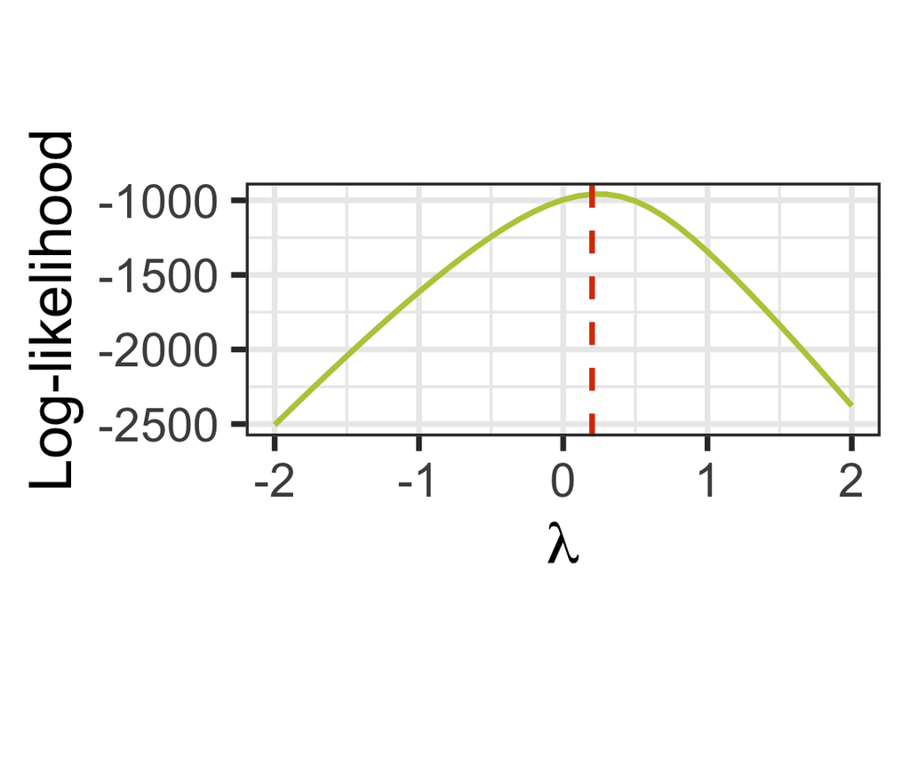

```r
bc_pm25 <- MASS::boxcox(pm25_shift ~ 1, plotit = FALSE)
lambda_pm25 <- bc_pm25$x[which.max(bc_pm25$y)]
tibble(lambda = bc_pm25$x, loglik = bc_pm25$y) |>
  ggplot(aes(x = lambda, y = loglik)) +
  geom_line(colour = "#b9ca4a") +
  geom_vline(xintercept = lambda_pm25, linetype = "dashed", colour = "#D93F00") +
  labs(x = expression(lambda), y = "Log-likelihood") +
  theme(aspect.ratio = 0.4)
```

Optimal $\lambda \approx$ 0.2

Transformed variable, using the optimal $\lambda$ directly (not rounded to a ladder rung):

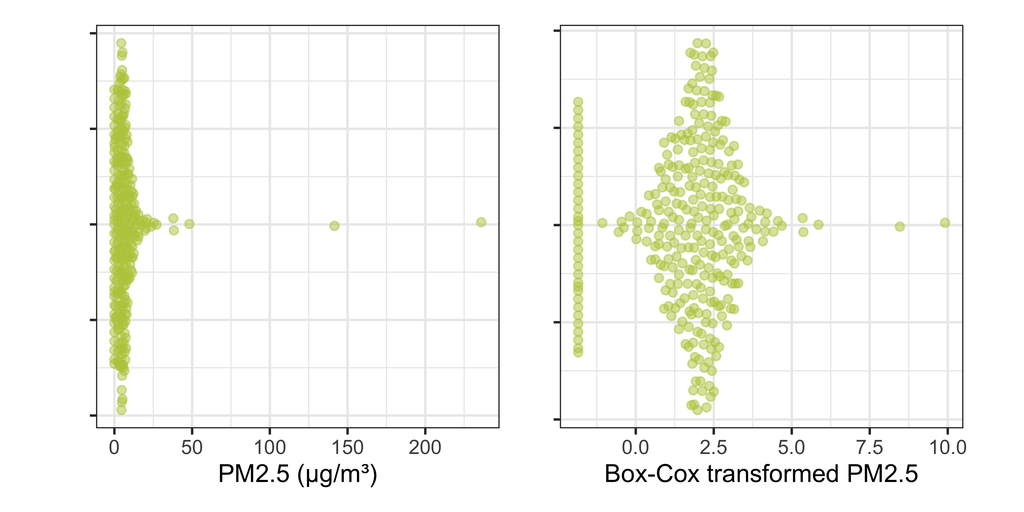

```r
pm25_bc <- (pm25_shift^lambda_pm25 - 1) / lambda_pm25
pm25p2 <- ggplot(tibble(pm25_bc = pm25_bc), aes(x = pm25_bc, y = 1)) +
  geom_quasirandom(colour = "#b9ca4a", alpha = 0.5) +
  ylab("") + xlab("Box-Cox transformed PM2.5") +
  theme(axis.text.y = element_blank())
pm25p1  + pm25p2 + plot_layout(ncol=2)
```

- Skewness before transforming: 11.04
- Skewness after transforming: -0.17

$\lambda \approx 0.2$ sits between $\sqrt{y}$ ($\lambda=0.5$) and $\log(y)$ ($\lambda=0$) on the ladder. Rounding to $\log(y)$ actually *overcorrects* here (skewness becomes -1.33, i.e. left-skewed) – a reminder that the optimal $\lambda$ is not always well-approximated by a “nice” rung when there are extreme outliers (here, from bushfire smoke).

```r
pm25 <- melb_air$pm25[!is.na(melb_air$pm25)]
pm25_shift <- pm25 + 0.1
pm25p1 <- ggplot(tibble(pm25 = pm25), aes(x = pm25, y = 1)) +
  geom_quasirandom(colour = "#b9ca4a", alpha = 0.5) +
  ylab("") + xlab("PM2.5 (µg/m³)") +
  theme(axis.text.y = element_blank())
```

```r
bc_pm25 <- MASS::boxcox(pm25_shift ~ 1, plotit = FALSE)
lambda_pm25 <- bc_pm25$x[which.max(bc_pm25$y)]
tibble(lambda = bc_pm25$x, loglik = bc_pm25$y) |>
  ggplot(aes(x = lambda, y = loglik)) +
  geom_line(colour = "#b9ca4a") +
  geom_vline(xintercept = lambda_pm25, linetype = "dashed", colour = "#D93F00") +
  labs(x = expression(lambda), y = "Log-likelihood") +
  theme(aspect.ratio = 0.4)
```

```r
pm25_bc <- (pm25_shift^lambda_pm25 - 1) / lambda_pm25
pm25p2 <- ggplot(tibble(pm25_bc = pm25_bc), aes(x = pm25_bc, y = 1)) +
  geom_quasirandom(colour = "#b9ca4a", alpha = 0.5) +
  ylab("") + xlab("Box-Cox transformed PM2.5") +
  theme(axis.text.y = element_blank())
pm25p1  + pm25p2 + plot_layout(ncol=2)
```